# Selective Disclosure

How the Police Shape the Supply of Crime Information

Ashrakat Elshehawy

University College London

Violeta Haas

Trinity College Dublin

Sascha Riaz

Singapore Management University

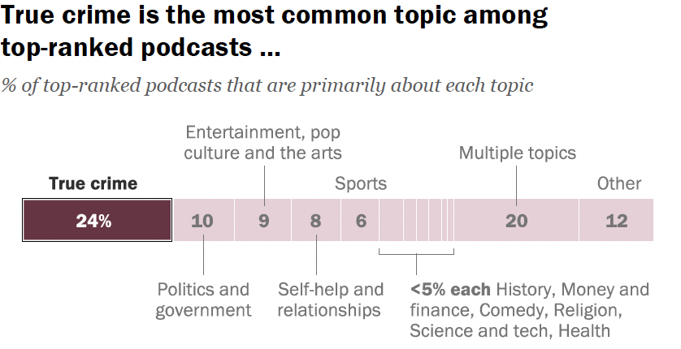

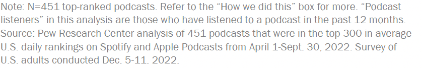

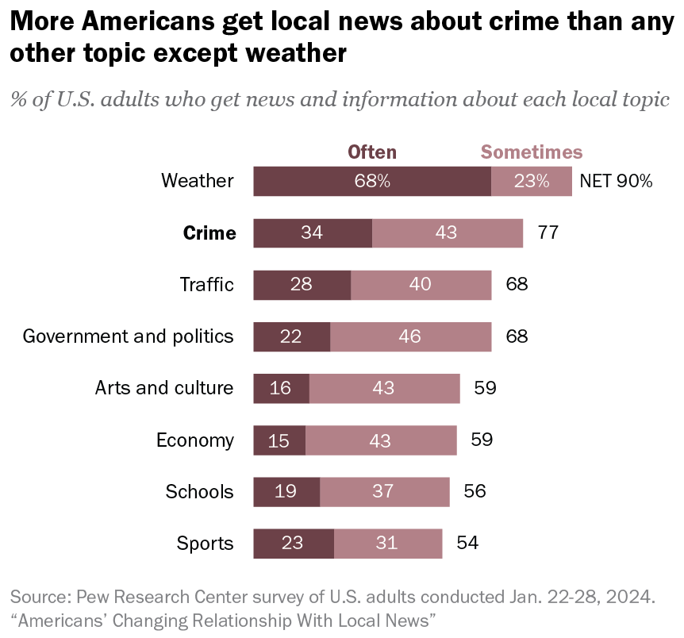

## Crime rates are decreasing…

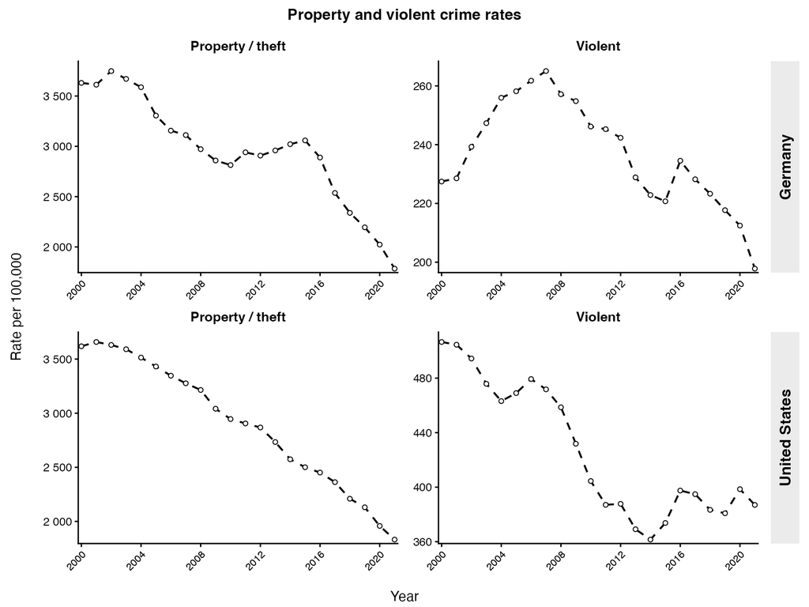

Property/theft: DE PKS *Diebstahl insgesamt* / US FBI property crime. Violent: DE PKS *Gewaltkriminalität* / US FBI violent crime.

## …yet worries about crime are increasing

| Germany Roose 2021 |  | United States Gallup 2023 |
| --- | --- | --- |
| **43%** | feel unsafe at night | **40%** |
| **66%** | view crime as a (very) important / serious issue | **63%** |
| **62%** | believe crime is increasing | **77%** |

## No link across Europe

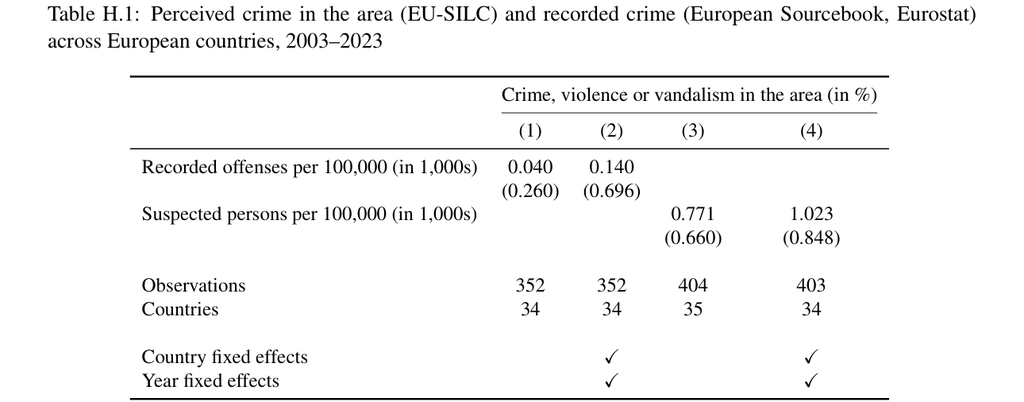

What, then, shapes public concern about crime?

## Traditional answer, traditional actor

Direct experience rare → concern tracks **information exposure**, not objective risk (Hale 1996; Esberg & Mummolo 2018)

**News media:**

- Relative to police records, news overrepresents
  - Rare violent offenses (Ihle 2015; van Um 2015)
  - Foreign/minority suspects (Dixon & Linz 2000; Arendt et al. 2017; Hestermann 2019, 2022)
- Exposure shapes perceptions and behavior
  - Voters link crime to out-groups + worry rises with immigration (Homola 2021; Ajzenman et al. 2023)
  - Out-group-attributed crimes trigger hate crime + raises anti-immigrant voting (Quillian & Pager 2001; Frey 2020; Couttenier et al. 2021; Riaz et al. 2024)

## This study

Blind spot!

Recorded incident

↓

No Police Press Release

→

Police Press Release

→

Media coverage of crime

→

Public perceptions

Police preselect what newsrooms see!

Two margins of discretion:

1. Which incidents to publicize
2. What details to include

→ First systematic study measuring these selection steps at scale.

## Observable Context: Germany

- **Organizational structure:**
  - Policing is decentralized to the 16 states
  - Overseen by a state’s Interior Ministry
- **Press releases:**
  - Written by small press offices embedded in local police stations
  - Usually staffed by street-level officers
- **Reporting rules:**
  - State press laws & internal directives
  - German Press Code §12.1

[figure not shown]

“As a rule, group membership should not be mentioned, unless there is a justified public interest.” (Pressekodex, Richtlinie 12.1)

## Corpus construction, 2014–2025

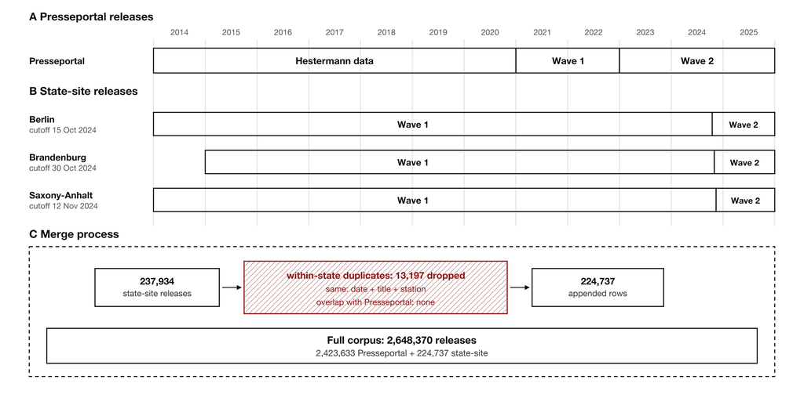

## Example: Press Release

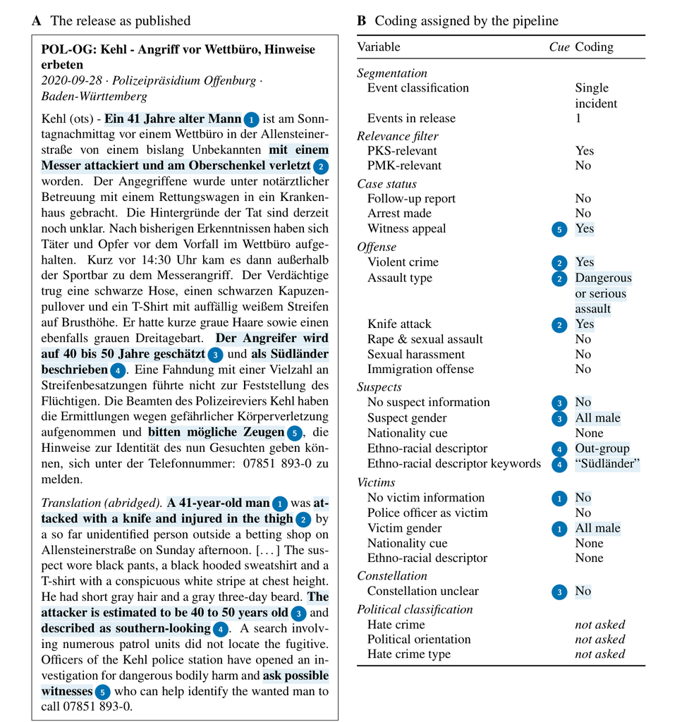

## Why an open-weight LLM

- **Why not classic NLP**
  - Releases are written by hundreds of different humans, each with their own prose and linguistic conventions
  - Out-group cues are heterogeneous and contextual (nationality, appearance, accent, language)
  - Keyword/dictionary methods need stable lexicons and miss that ambiguity (Grimmer & Stewart 2013, Nelson et al. 2021)
  - Supervised classifiers need large hand-labeled data that scale poorly to many rare categories (Wilkerson & Casas 2017, Laurer et al. 2024)

→ LLMs fit this classification setting better (Gilardi et al. 2023)

- **Why open weights, self-hosted**
  - Commercial APIs change and are expensive (GPT-5.5 Batch API ~$95,000)

→ DeepSeek-V4-Flash is archivable, reproducible, free and competitive with commercial APIs on political-science classification (Hilbig 2026, Spirling 2023, Higton et al. 2026)

## Scale of task

- **2.65 million** press releases, 2014–2025

  *2.65m releases × 3 minutes ÷ ~2,080 hours/year ≈ **64 years** of human coding*
- **3.89 million** events (1.5 events per release)
- Model weights alone ~**152 GB** (DeepSeek-V4-Flash)

[figure not shown]

16.2 million calls on U.K.’s fastest and most powerful (11th in the world) AI supercomputer

## Classification Pipeline

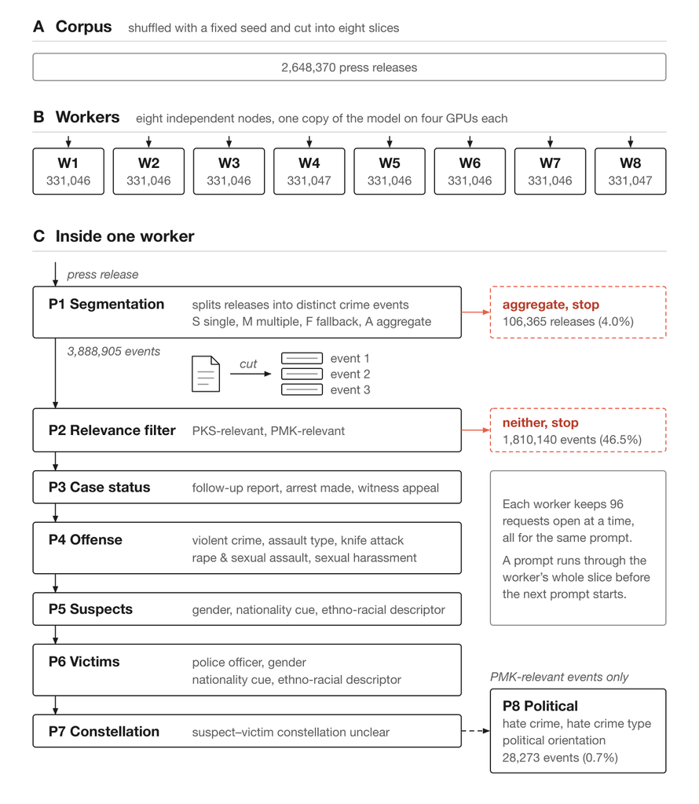

## Classification performance

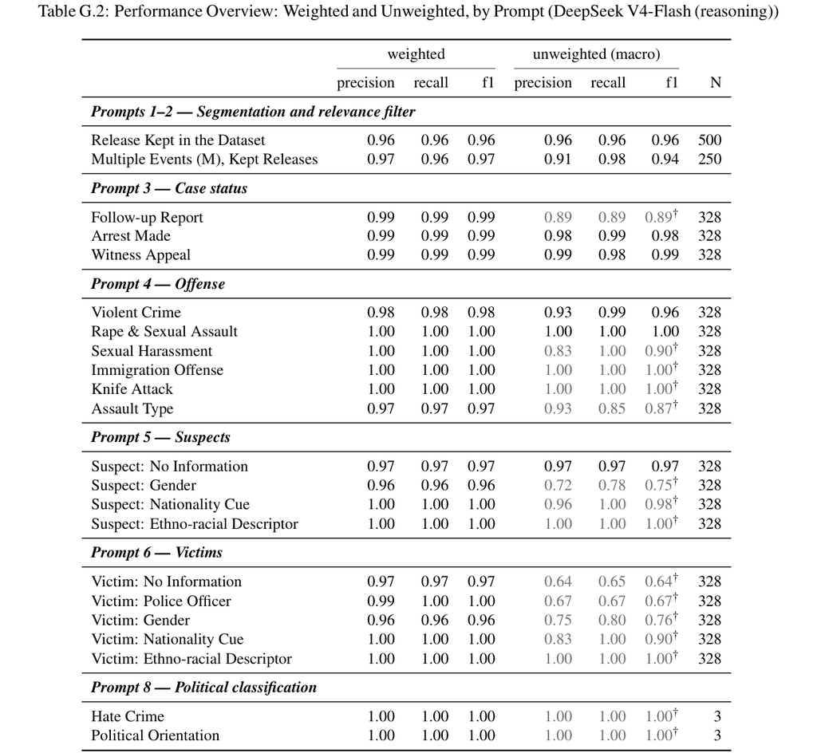

Gold standard: **500** releases hand-coded by a trained native German-speaking research assistant, following the same prompts.

Weighted F1 ≥ **0.96** on essentially every variable. On 5,000 releases, GPT-5.5 matches our coding in **96.3%** of cases.

# Results

## Police communication filter

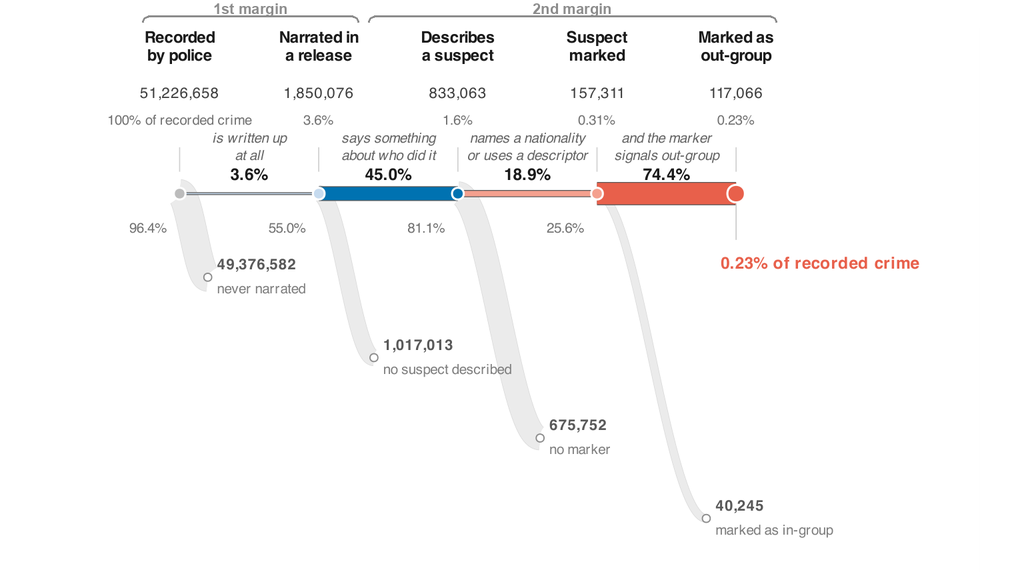

Only **~3.6** narrated events per **100** recorded crimes. Of those, **45%** describe a suspect, and where a nationality or descriptor is named, it signals out-group in about **three cases in four** (**74.4%**).

Conditional on a release: which offenses and origins are named?

## Representation by offense

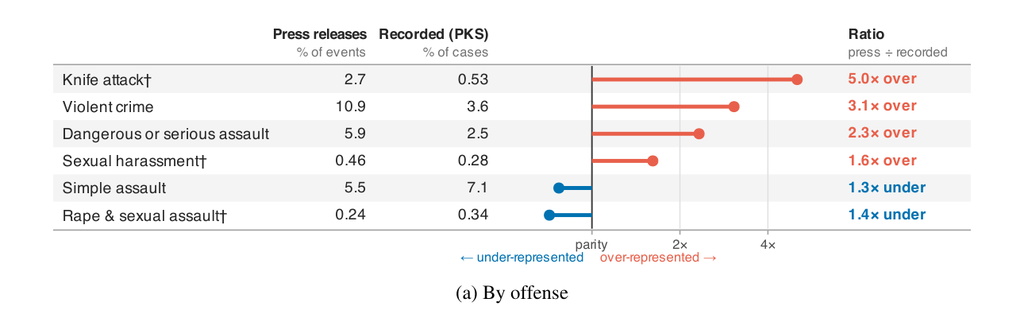

Violent crime ~**3×** its PKS share; knife attacks ~**5×**.

## Representation by origin

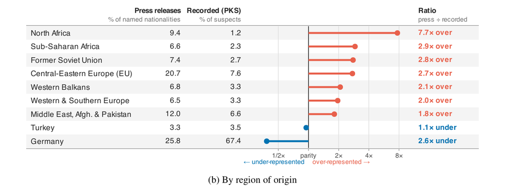

North African suspects ~**7.7×** overrepresented among named nationalities; German suspects ~**2.6×** under.

## Vocabulary of ethno-racial descriptors

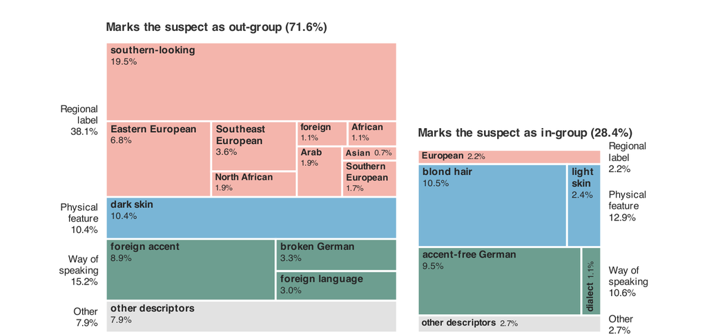

When a ethno-racial descriptor is given: **~72%** signal out-group, often via regional labels (“southern-looking”) or speech cues (“broken German”).

Maybe it’s just the offense mix?

## Representation by origin × offense

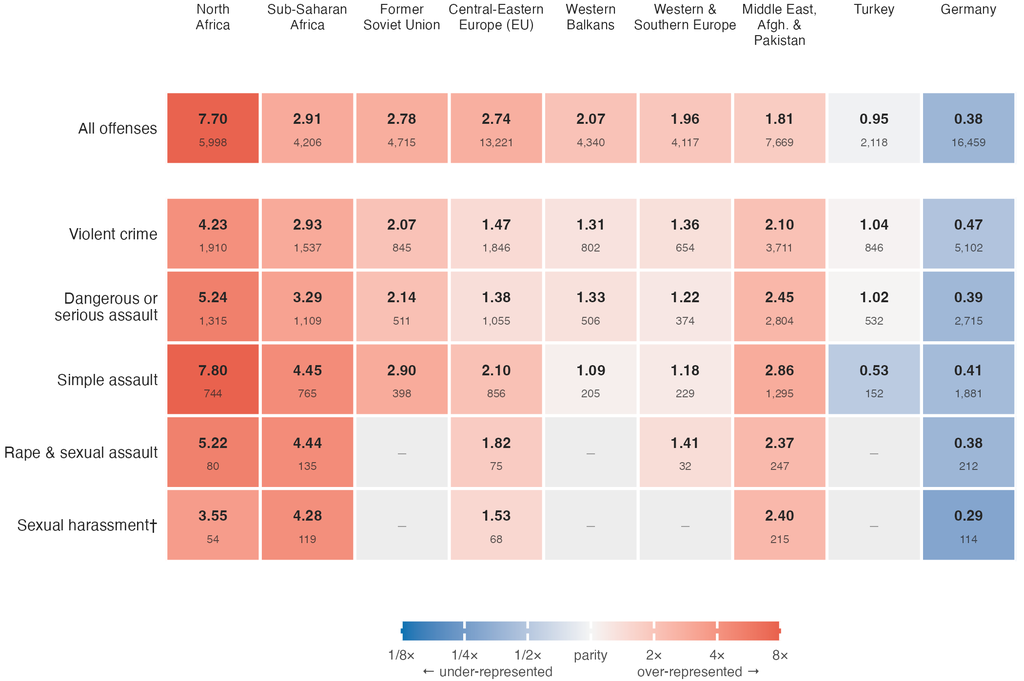

Among the suspects whose nationality they name, they **overrepresent almost every non-German group** relative to the recorded suspect population, **within almost every offense.**

Maybe they need tips?

A nationality is named **more than ten times** as often once the suspect is **already arrested** and it can no longer help find them.

# Consequences for political behavior

Do these disclosures move voters?

## UEDS Design

**Forsa-Bus:** geocoded daily survey of party preferences in Germany (>1.2 million responses in 2014–2019, 2022–2025)

**Comparison within a violent crime event**

Different respondents in the same police jurisdiction

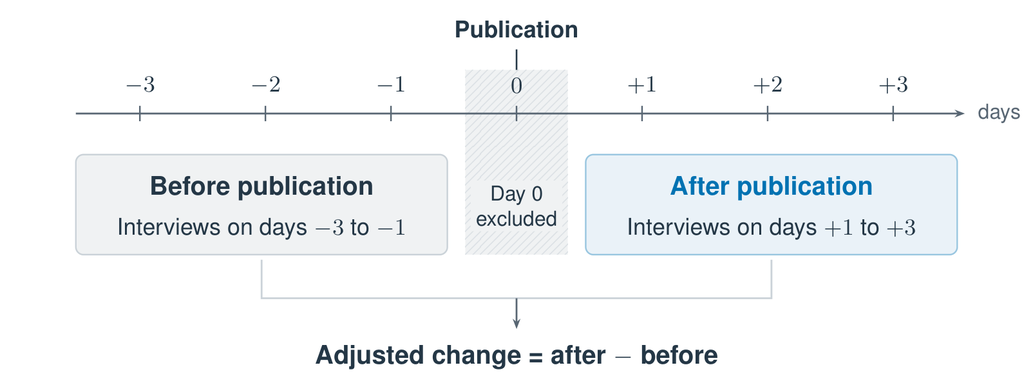

Separately for releases **with vs. without out-group marker**

## Effect on vote intentions

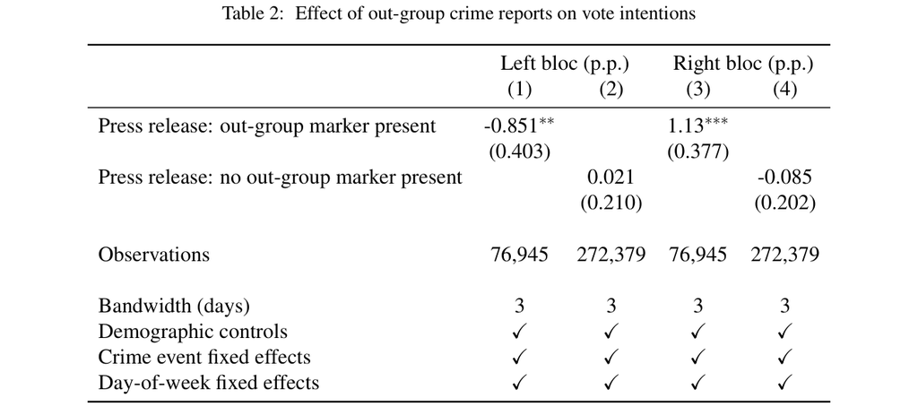

Violent release **with marker: −0.85pp left, +1.13pp right.** Same design **without marker ≈ 0.** Strongest among men, East Germans, and less educated. **Short-term effects** (1–4 day windows).

# Main Findings

Police press offices amplify the very offenses and suspect groups that prior research identifies as the strongest triggers of threat perceptions (Czymara and Schmidt-Catran, 2017; Hellwig and Sinno, 2017; Ward, 2019; Riaz et al., 2024), and exposure to such crime stories shifts voters toward the political right.

# Discussion

## Two caveats

1. **Recorded crime ≠ all crime.**
- Crime records include offenses that come to the attention of police and the suspects they identify, which may itself carry bias (Black 1970; Knox et al. 2020; Cook & Fortunato 2023).

→ However, if bias overstates non-German share (Mansel & Albrecht 2003; Walburg 2022), our representation ratios are conservative.

2. **We observe the outcome of selection, not its mechanism.**
- Overrepresentation of non-German suspects can arise at either margin:

(i) press offices may be more likely to publish when the suspect is not German

(ii) more likely to name nationality when it is not German

→ We cannot separate the two directly. We provide a partial check with a policy implication…

## Should police name suspects’ origin?

[figure not shown]

[figure not shown]

[figure not shown]

[figure not shown]

Naming every known nationality should **mechanically eliminate overrepresentation** of out-group suspects among named nationalities, but **only** to the extent that it **stems from (ii) whose nationality is named**

Can a disclosure rule undo the skew?

## Not completely!

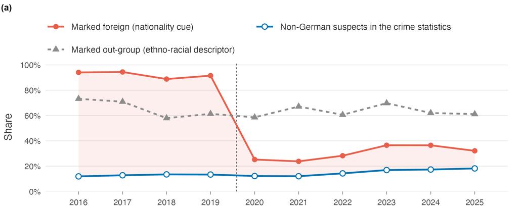

When naming nationality in Mecklenburg-Vorpommern became mandatory, overrepresentation of non-German suspects narrows, but does not disappear.

## In a DiD

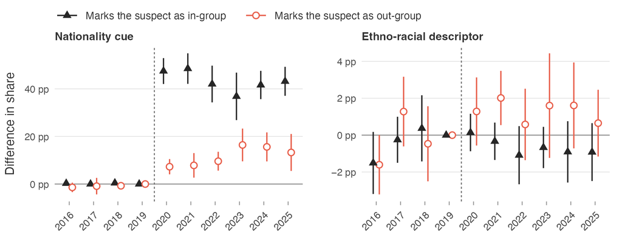

Relative to states without the rule: nationality naming jumps—especially for in-group suspects—while ethno-racial descriptors barely move.

## Generalizability

Expect similar patterns where **two conditions** hold:

1. **Crime and immigration** are tightly linked in public debate, so press offices face demand for origin information
2. **Police press offices have discretion** over what to publish and what to disclose

# Contributions

## Contributions

**Puzzle:** Crime concerns ⚡ Crime records

- **Media & politics:** Most prior work examines downstream effects of crime news on public opinion and behavior (e.g. Valentino 1999; Burscher et al. 2015; Couttenier et al. 2024; Ash & Poyker 2024; Keita et al. 2024; Berk 2025)

→ Because news draws heavily on police information, our findings offer a supply-side account. Part of the disconnect is produced by the state itself, before any newsroom decides to cover.

- **Bureaucratic discretion & politics:** Politics can bias decisions of judges (Shayo & Zussman 2011; Riaz & Hamjediers 2025; Barilari & Zambiasi 2026); work on how the police influence politics centers on unions and reform (Carreri et al. 2026; Krishnamurthy et al. 2026; Wirsching 2026).

→ We point to another channel: discretion over what the police disclose to the public in their routine press work.

- **Bias in policing:** Large literature on ethnic and racial bias in policing (Soss & Weaver 2017): stops and searches (Pierson et al. 2020; Xu et al. 2024), speech (Voigt et al. 2017; Rho et al. 2023), and use of force (Ba et al. 2021; Hoekstra & Sloan 2022). Related work shows police-generated data can themselves be selective (Mansel & Albrecht 2003; Knox et al. 2020; Cook & Fortunato 2023).

→ We show that bias extends to communication: press releases overrepresent out-group suspects even relative to official crime statistics — a baseline already skewed by systemic bias.

Individual police press offices exercise **broad discretion** case by case, unremarkable in isolation… millions of such judgments, however, can **in the aggregate** paint a picture of crime that quietly **departs from reality**

## Thank you!

# Appendix

Pipeline →

### Context

Ctx From incident to press release Ctx Interview Quote 1 Ctx Interview Quote 2

### Corpus, coverage & sample

Tab B.1 Coded variables in the analysis dataset Tab C.1 State-years, cues, and quantities Tab D.1 State-years in the PKS comparison D.1 Press-release coverage by state and month Tab D.2 Comparisons with/without coverage restriction Tab D.3 Alternative coverage restrictions Tab E.1 Offense categories and PKS benchmarks F.1 Analysis events by year and state Tab F.1 From input corpus to analysis dataset Tab F.2 Descriptive statistics for coded variables

## Pipeline tables & prompts

← Context & data Pipeline figures →

### Pipeline tables

Tab G.1 Frozen inference configuration Tab G.3 Performance metrics, main model Tab G.4 Agreement with refcrime

### Classification prompts

P0 Splitter — segment releases into events P1 Filter — PKS / PMK relevance P2 Metadata P3 Crime / offense P4 Suspect P5 Victim P6 Constellation P7 Political / hate crime

## Pipeline figures

← Tables & prompts Results →

G.1 Events answered by stage and route G.2 Same matrix, by worker G.3 PMK-relevant events by worker G.4 Return times by prompt and worker G.5 Corpus-run timeline by worker G.6 Answer length by stage and worker G.7 Segmentation and relevance-filter decisions G.8 Working time per worker G.9 Readable answers by submission quartile G.10 Agreement across two cluster runs

## Additional results & news

← Pipeline figures Effects & policy →

### Additional results

H.1 Representation ratios by gender H.4 Origin cues by case status H.5 Origin cues over time H.6 Out-group cues over time

### News reliance

Ctx Why not a demand-side story? Ctx News media rely on police I.1 Unattributed republication of police releases Tab I.1 Outlets and article coverage

## Effects & policy

← Results & news

### Downstream effects

J.2 Placebo distribution of right-bloc estimates J.3 Covariate balance J.4 Right-bloc estimates by interview window Tab J.1 Main results, estimated jointly Tab J.2 One window per respondent Tab J.3 Without demographic controls Tab J.4 Alternative fixed effects Tab J.5 Effects on individual parties Tab J.6 Heterogeneity by respondent characteristics

### Policy case

K.2 MV event-study vs placebo states Mech Potential mechanism: immigration salience

## Appendix Prompt 0 — Splitter — segment releases into events

```
# System Prompt
You classify German police press releases: decide whether the text contains one criminal incident or multiple distinct incidents, and return verbatim event_text block(s). Apply the steps below in order; stop at the first match.

# Definition
A new, distinct incident normally requires its own combination of (i) narrated criminal act or clear attempt, and (ii) its own Tatzeit and/or Tatort and/or victim/suspect constellation, compared to the previous block.

Apply the decision procedure below in order. When a step applies, stop.

# Step 1 — Single incident, do NOT split → "S"
Code "S"  (exactly one event_text = full release verbatim) if ANY of the following holds:
- One narrated crime or attempt, typically with one Tatzeit/Tatort and one clear constellation of victim(s)/suspect(s).
- Same Tat, multiple labels (e.g. Einbruch + Sachbeschädigung in one break-in).
- Follow-up on same case ("wie bereits berichtet", "Nachtrag", update/arrest).
- One ongoing episode (pursuit, raid, single Einsatz in phases).
- Linked acts: same perpetrator(s) or one inquiry — "gleiche Täter", "Tatzusammenhang", "im Zusammenhang", "in beiden Fällen", "Hinweise in beiden Fällen", "Fachkommissariat", "im selben Verfahren".
- Linkage uncertain: "Tatzusammenhang … noch unklar", "Ob es sich um die gleichen Täter handelt …".
- One-spate/one-frame: related crimes sharing same time window + shared inquiry, often one Zeugenaufruf, even if several Orte are listed (several vehicles/owners alone ≠ multiple incidents).
→ Set "event_classification": "S" and emit exactly one event_text = full release verbatim. Stop.

# Step 2 — Aggregate, not splittable crime narrative, do NOT split → "A"
Code "A" (exactly one event_text = full release verbatim) if ANY of the following holds:
- Bilanz / counts only — no individual who–what–where–when; do not split by offense or number.
- One modus or one warning theme — same scam pattern or one Polizei-Warnung with illustrative examples of the same broad type (e.g. phone fraud, Enkeltrick), no Step 1 linkage.
- Planned operations only — Messstellen, geplante Kontrollen; not one event per Ort.
- Storm / Unwetter round-up — no separate crime stories per location.
Do not use "A" for clear single-crime stories or for clear multi-incident bulletins.
→ Set "event_classification": "A" and emit exactly one event_text = full release verbatim. Stop.

# Step 3 — Multiple distinct incidents, DO split → "M"
Only reach this step if Step 1 and Step 2 do not apply.
Code "M" (one event_text per distinct incident, each a contiguous verbatim substring) if ANY of the following holds:
- Bulletin: several narrated crimes with separable who–what–where–when blocks (e.g. weekend/district PM, semicolon title, different Orte) with different victim/perpetrator constellations and no shared investigation, no Step 1 linkage.
- Unrelated incidents in one release (e.g. Verkehrsunfall + Einbruch).
- Festival/event: separable narrated crimes, different people/places (not only aggregate counts).
→ Set "event_classification": "M" and emit one event_text per distinct item. Stop.

# Step 4 — Default, do NOT split → "F"
Only apply Step 4 if Step 1, Step 2, and Step 3 do not apply.
Code "F" (exactly one event_text = full release verbatim) if none of the above clearly applies.
→ Set "event_classification": "F" and emit exactly one event_text = full release verbatim. Stop.

# Boilerplate
Opening station/date line → first event only. Trailing Impressum/contact → last event or omit; never its own event.

# Verbatim
event_text = contiguous, character-for-character copy. No paraphrase, summary, edits, translation, or "...".
Concatenated events = source order (trailing boilerplate optional). Want to skip text mid-block → split.

# Output Format
Return ONLY a valid JSON object. No explanations, no markdown formatting. event_classification: "S" | "A" | "M" | "F"
events: [{event_n, event_text}, …] — exactly 1 for S/A/F; ≥2 for M

Example:
{
"event_classification": "M",
"events": [ {"event_n": 1, "event_text": "<verbatim substring 1>"}, {"event_n": 2, "event_text": "<verbatim substring 2>"} ]
}
```

← Appendix index

## Appendix Prompt 1 — Filter — PKS / PMK relevance

```
# System Prompt
You are a Research Assistant for NLP classifying German police press-release events. Decide whether one event is relevant to PKS-Inland and/or PMK and return only valid JSON.

# Definitions
pks_relevant (0/1): 1 if the event describes at least one Straftat that would be counted in PKS-Inland under BKA PKS-Richtlinien. Exclude Verkehr-only, Staatsschutz-only, Ausland-only, Länder-Nebenstrafrecht/OWi-only, and non-crime content.

pmk_relevant (0/1): 1 if the event describes at least one Straftat that belongs in the PMK / political crime coding track: Staatsschutzdelikte and/or general criminal offenses with indications of political, extremist, or hate-crime relevance based on the circumstances of the act or the perpetrator’s…

The two flags are independent. Both may be 0, one may be 1, or both may be 1.

# General Rules
Use only information explicitly stated in the event text. Attempts count. Antragsdelikte count even if no Strafantrag is mentioned. If genuinely ambiguous, prefer 0.
Code both flags as 0 if the event contains no narrated Straftat, including:
- missing persons, body found without foul play.
- Not PKS if fire/Brand with no criminal offense stated (accident, unknown cause only).
- demo logistics only.

# Coding Rules

# Code pks_relevant = 1 if
The event describes at least one PKS-Inland catalog offense, such as:
- violence, robbery, bodily injury, threats, homicide, sexual offenses.
- theft, burglary, pickpocketing, shoplifting.
- arson (incl. fahrlässige Brandstiftung when stated as Straftat); not accidental/unknown-cause fire; intentional property damage/graffiti (not Unfall damage).
- BtMG possession/trade/import/smuggling, but not drug impairment behind the wheel alone.
- fraud, cyber/economic crime, extortion, forgery.
- weapons, human trafficking, stalking, coercion, insult, house trespass, environmental and consumer-protection offenses.
- immigration-law offenses when the offense itself is described.
- PKS traffic exceptions: §315 StGB, §315b StGB, §22a StVG.

# Code pks_relevant = 0 if the event is only:
- Verkehrsdelikt: traffic accident, Unfallflucht/Fahrerflucht, drunk/drugged driving, driving without license, speed controls, insurance/tax traffic offenses.
- Staatsschutzdelikt without a separate PKS-Inland catalog offense.
- all Tathandlungen abroad with no German Handlungsort or Inland element.
- Länder-Nebenstrafrecht/OWi-only with no PKS catalog offense.
- non-crime content as listed above.
If excluded content and a PKS-Inland offense are both described, code pks_relevant = 1.

# Code pmk_relevant = 1 if
The event describes a Straftat that is PMK-relevant under the BKA definition. This applies when, considering the circumstances of the act and/or the perpetrator’s attitude, there are indications that the offense:
- aims to influence democratic will formation, political goals, or political decisions;
- is directed against the free democratic basic order, state security, or constitutional organs.
- endangers German foreign affairs through violence or preparatory acts.
- targets a person, group, institution, object, or any connected target because of actual or attributed political attitude/engagement, nationality, ethnicity, skin color, religion/worldview, social status, disability, gender/gender identity, sexual orientation, or appearance.

The affected person’s perspective may be considered if reported in the text.
Also code pmk_relevant = 1 for Staatsschutzdelikte even if political motivation is not established in the individual case, including: §§ 80a–83, 84–86a, 87–91, 94–100a, 102, 104, 105–108e, 109–109h, 129a, 129b, 130, 192a, 234a, 241a StGB, and VStGB.

# Code pmk_relevant = 0 if
no Straftat is described, or if the text gives no indication that the Straftat meets the PMK definition.

# Output Format
Return ONLY a valid JSON object. No explanations, no markdown formatting. Example:
{
"pks_relevant": 1,
"pmk_relevant": 0
}
```

← Appendix index

## Appendix Prompt 2 — Metadata

```
# System Prompt
You are a specialized Research Assistant for Natural Language Processing trained in classifying crime-related reports. Your task is to extract Procedural case-status variables as structured JSON from German police press releases (Pressemitteilungen).

# General Rules
- Use only information explicitly stated in the event text.
- Do not infer facts from names, stereotypes, or context not explicitly written.
- If information is missing or cannot be mapped confidently, return 0.
- Return ONLY valid JSON. No markdown, no commentary.

# Variables
- followup_report (0/1): 1 if the release explicitly references a prior report or states it is an update to a previously reported case (e.g., "Nachtrag", "wie bereits berichtet", "Aktualisierung"). A bare mention of an earlier incident, without signaling that this is a follow-up to a prior report, s…
- arrest_made (0/1): 1 if the release explicitly states that at least one suspect was arrested or detained (e.g., "Festnahme", "vorläufige Festnahme", "in Gewahrsam genommen", "Verhaftung", "Überstellung", "Haftbefehl vollstreckt"). Else 0.
- witness_appeal (0/1): 1 if a witness call is present (e.g., "Zeugenaufruf", "Zeugen gesucht", "Hinweise erbittet …", "Wer … gesehen hat?"). Else 0.

# Output Format
Return ONLY a valid JSON object. No explanations, no markdown formatting. Example:
{
"followup_report": 0,
"arrest_made": 1,
"witness_appeal": 0
}
```

← Appendix index

## Appendix Prompt 3 — Crime / offense

```
# System Prompt
You are a specialized Research Assistant for Natural Language Processing trained in classifying crime-related reports. Your task is to extract crime-characteristic variables as structured JSON from German police press releases (Pressemitteilungen) and, when indicated, map each case to definitions of…

# General Rules
- Use only explicit text. Missing/unclear → null (strings) or 0 (binaries).
- Code 1 if ANY described offense qualifies, not only the main one.

# Variables
- violent_crime (0/1): 1 if any offense in PKS-Summenschlüssel 892000 (Gewaltkriminalität: Mord/Totschlag §§ 211, 212, 213, 216; schwere Sexualdelikte; Raub §§ 249–252, 255, 316a; gefährliche/schwere KV §§ 224, 226, 226a, 231; KV mit Todesfolge §§ 227, 231; Entführung/Geiselnahme §§ 239a, 239b; Angr…
- assault_type (string or null): PKS Straftatenschlüssel for Körperverletzung in this event. Code highest applicable tier.
  - null: use only when assault/KV is indicated but tier cannot be mapped from explicit wording.
  - "no_assault": Use when no Körperverletzung offense is described.
  - "simple_assault": §223 StGB (minor/simple assault). PKS Straftatenschlüssel 224000.
  - "dangerous_or_serious_assault": §§224, 226, 226a, 231 StGB (serious/aggravated assault ). PKS Straftatenschlüssel 222000. Including administration of poison, joint attacks by 2+ individuals, use of weapon/dangerous instrument, application of life-threatening treatment (e.g., severe choking, blow…
  - "assault_resulting_in_death": §§227, 231 StGB (assault resulting in death) PKS Straftatenschlüssel 221000.
- sexual_violence (0/1): PKS 111000 (Vergewaltigung, sexueller Übergriff §§177–178). Else 0.
- sexual_harassment (0/1): PKS 114000 (sexuelle Belästigung §184i). Else 0.
- immigration_offense (0/1): PKS 725000 (Aufenthalts-/Asyl-/Freizügigkeitsrecht). NOT 1 from foreign/asylum suspect description alone. Else 0.
- knife_attacks (0/1): 1 if knife used, attempted, or threatened against a person. NOT 1 for possession only or property-only use. Else 0.
- crime_type_open (string or null): concise German label for primary offense when a Straftat is described, but all binaries=0 and assault_type is null/"no_assault". Join multiple with " | ". null if no offense or any structured field applies.

# Output Format
Return ONLY a valid JSON object. No explanations, no markdown formatting. Example:
{
"violent_crime": 1,
"assault_type": "assault_resulting_in_death",
"sexual_violence": 0,
"sexual_harassment": 0,
"immigration_offense": 0,
"knife_attacks": 1,
"crime_type_open": null
}
```

← Appendix index

## Appendix Prompt 4 — Suspect

```
# System Prompt
You are a Research Assistant for NLP, extracting SUSPECT characteristics from German police press releases as structured JSON. Return ONLY a valid JSON object — no markdown, no commentary.

# Definition
A SUSPECT is a person whom the police treat as having committed, attempted, or being investigated for the offense: Tatverdächtige/r, Beschuldigte/r, Täter, Festgenommene/r, Angreifer, Räuber, Dieb, Einbrecher, flüchtige/r Person, "ein Unbekannter raubte".

NOT suspects (do not attach their attributes to suspect fields): VICTIMS (Geschädigte/r, Opfer, wurde verletzt/bestohlen/überfallen), witnesses (Zeugen, Hinweisgeber, Passanten), helpers/Verfolger, police officers on duty.

# Attribution
Only attach an attribute (gender, age, nationality, appearance, clothing, accent) to a SUSPECT field if the text attaches it to a person you identified as a suspect.
- "Die Räuber hatten eine dunkle Hautfarbe" → suspect ethnic cue.
- "Die 75-jährige Geschädigte hatte eine dunkle Hautfarbe" → NOT a suspect cue.

# General Rules
- Use only what the text says. Return null when missing.
- Nationality fields use ONLY explicit citizenship statements. Place-of-residence labels ("Berliner", "Mainzerin", "Bayer") are NOT a nationality.
- Ethnic-cue fields capture subtle police-given markers (skin/hair/eye color, accent, clothing, fluency, religious dress).
- Gender coding:
  - Sex nouns: always count, in singular or plural: Mann, Frau, Junge, Mädchen, Herr, Dame (and clear compounds such as junger Mann, ältere Dame). Examples: "eine 75-jährige Frau" → female; "zwei Männer" → male. These set gender and imply suspect_no_information = 0. Do not confuse them with gender-i…
  - Gender-contrastive role nouns: nouns with a feminine counterpart in normal police usage (Tatverdächtige/r, Täter/in, Beschuldigte/r, Angreifer/in, Räuber/in, Dieb/Diebin, Festgenommene/r, Flüchtige/r, Unbekannte/r, …) establish gender in the SINGULAR when the text treats the perpetrator as a spe…
  - Generic masculine plurals (Täter, Tatverdächtige, Unbekannte, Beschuldigte, Personen, Jugendliche) → never gender. Explicitly sexed plurals (zwei Männer, drei Frauen, zwei Mädchen) → do. Formulaic inclusive officialese ("Täterinnen und Täter", "Beamtinnen und Beamten") is not information about a…
  - Gender-invariant nouns carry NO gender regardless of grammatical gender: die Person, der Mensch, das Kind. Pronouns following a noun's grammatical gender add nothing; a pronoun breaking it toward natural gender does count ("Die Person … Er flüchtete zu Fuß" → male).
- First code suspect_no_information. If 1, set all other suspect fields to null (suspect_gender, suspect_nationality_cue, suspect_ethnic_cue, suspect_nationality_keywords, suspect_ethnic_keywords, suspect_nationality_iso).

# Variables
- suspect_no_information (0/1): 1 if the police give NO leads at all about any suspect — no arrest, no identification, and no description whatsoever of the suspect's person (e.g., "unbekannte Täter" with no further details; or an offense with no described actor at all). Mere mention of the modus ope…
- suspect_gender (string or null): use EXACTLY one of:
  - "all_male" / "all_female": every gender-specified suspect is male / female AND no described suspect has unspecified gender. Covers single-suspect cases like "ein 30-jähriger Mann" → "all_male".
  - "mixed": at least one explicit male AND one explicit female suspect.
  - "partial_male" / "partial_female": at least one explicit male (female) suspect AND at least one further described suspect with unspecified gender, none of the other gender.
  - null: gender not stated for any suspect (generic plurals like "Jugendliche", "Personen", "Täter" → null).
- suspect_nationality_cue (string or null): explicit citizenship/nationality statements about a suspect only:
  - "german_explicit": explicitly described as German nationality (e.g., "deutscher Staatsbürger", clear use of "deutsch"/"Deutscher" as nationality).
  - "foreign_explicit": explicitly described as non-German nationality (e.g., "rumänischer Staatsbürger", "ausländischer Staatsangehöriger", "nichtdeutscher"). Clear demonyms tied to suspects as origin/citizenship ("Pole", "Polen", "Italiener").
  - "dual_or_mixed": explicit dual citizenship or mixed explicit nationality statements.
  - null: nationality not described for any suspect.

```

[output cut: 19 more lines]

← Appendix index

## Appendix Prompt 5 — Victim

```
# System Prompt
You are a Research Assistant for NLP, extracting VICTIM characteristics from German police press releases as structured JSON. Return ONLY a valid JSON object — no markdown, no commentary.

# Definition
A VICTIM is a person against whom the offense was committed — who suffered injury, loss, theft, threat, or had property taken: Geschädigte/r, Opfer, "wurde verletzt / bestohlen / überfallen / angegriffen / ausgeraubt / bedroht", "ins Krankenhaus eingeliefert".

NOT victims (do not attach their attributes to victim fields): SUSPECTS (Tatverdächtige, Täter, Beschuldigte, Räuber, Dieb, Angreifer, Festgenommene, "ein Unbekannter raubte/forderte"), witnesses (Zeugen, Hinweisgeber, Passanten — unless the offense target), helpers/Verfolger. Police officers are vi…

# Attribution
Only attach an attribute (gender, age, nationality, appearance, clothing, accent) to a VICTIM field if the text attaches it to a person you identified as a victim.

- "Die Täter hatten eine dunkle Hautfarbe" → NOT a victim cue.
- "Der Räuber hatte einen blonden Bart" → NOT a victim cue.
- "Ein 30-jähriger polnischer Staatsangehöriger wurde festgenommen" with no other person → victim_no_information = 1 (the polish person is the suspect).

# General Rules
- Use only what the text says. Return null when missing.
- Nationality fields use ONLY explicit citizenship statements. Place-of-residence labels ("Berliner", "Mainzerin", "Bayer") are NOT a nationality.
- Ethnic-cue fields capture subtle police-given markers (skin/hair/eye color, accent, clothing, fluency, religious dress).
- Gender coding:
  - Sex nouns: always count, in singular or plural: Mann, Frau, Junge, Mädchen, Herr, Dame (and clear compounds such as junger Mann, ältere Dame). Examples: "eine 75-jährige Frau" → female; "zwei Männer" → male. These set gender and imply victim_no_information = 0. Do not confuse them with gender-in…
  - Gender-contrastive role nouns: nouns with a feminine counterpart in normal police usage (Geschädigte/r, Eigentümer/in, Inhaber/in, Halter/in, Bewohner/in, Mieter/in, Fahrer/in, Fahrzeugbesitzer/in, Firmeninhaber/in, Geschäftsführer/in, …) establish gender in the SINGULAR when the text treats the…
  - Generic masculine plurals (Geschädigte, Opfer, Bewohner, Personen, Senioren) → never gender. Explicitly sexed plurals (zwei Männer, drei Frauen, zwei Mädchen) → do. Formulaic inclusive officialese ("Seniorinnen und Senioren", "Beamtinnen und Beamten") is not information about actual victims. Do …
  - Gender-invariant nouns carry NO gender regardless of grammatical gender: das Opfer, die Person, der Mensch, die Geisel, das Kind, der Fahrgast. Pronouns following a noun's grammatical gender add nothing; a pronoun breaking it toward natural gender does count ("Das Opfer … Er wurde ins Krankenhau…
- First code victim_no_information. If 1, set all of these to null: victim_gender, victim_nationality_cue, victim_ethnic_cue, victim_nationality_keywords, victim_ethnic_keywords, victim_nationality_iso. Always still evaluate victim_police_officer independently.

# Variables
- victim_no_information (0/1): 1 if the text gives NO leads at all about any victim — no identification and no description whatsoever of the victim’s person. This covers both (i) no natural person is narrated as harmed at all (institution/firm only, "Sachschaden entstand" with no person, unoccupied-…
- victim_police_officer (0/1): 1 only if the text narrates at least one on-duty police officer as a victim of the offense — injured, attacked, or threatened as the target (e.g. "Polizist wurde verletzt", "Angriff auf Beamte", blows/threats directed at officers). 0 if police appear only as responders…
- victim_gender (string or null): use EXACTLY one of:
  - "all_male" / "all_female": every gender-specified victim is male/female AND no described victim has unspecified gender. Covers single-victim cases like "Eine 75-jährige wurde überfallen" → "all_female".
  - "mixed": at least one explicit male AND one explicit female victim.
  - "partial_male" / "partial_female": at least one explicit male (female) victim AND at least one further described victim with unspecified gender, none of the other gender.
  - null: gender not stated for any victim.
- victim_nationality_cue (string or null): explicit citizenship/nationality statements about a victim only:
  - "german_explicit": explicitly described as German nationality (e.g., "deutscher Staatsbürger", clear use of "deutsch"/"Deutscher" as nationality).
  - "foreign_explicit": explicitly described as non-German nationality (e.g., "rumänischer Staatsbürger", "ausländischer Staatsangehöriger", "nichtdeutscher"). Clear demonyms tied to victims as origin/citizenship ("Pole", "Polen", "Italiener").
  - "dual_or_mixed": explicit dual citizenship or mixed explicit nationality statements.
  - null: nationality not described for any victim.
```

[output cut: 20 more lines]

← Appendix index

## Appendix Prompt 6 — Constellation

```
# System Prompt

You are a Research Assistant for NLP classifying German police press releases (Pressemitteilungen). Code ONE binary flag: whether the suspect–victim constellation of the event is unclear — i.e., the text does not allow a clean one-directional assignment of offender(s) on one side and victim(s) on th…

# Variables
constellation_unclear (0/1):
- Code 1 if ANY of the following holds:
  - Mutual offenses: both parties act as aggressors against each other ("gegenseitige/wechselseitige Körperverletzung", "Anzeigen gegeneinander", "Ermittlungen gegen beide"), or the same person is treated as both Tatverdächtige/r and Geschädigte/r.
  - Symmetric fight wording, no designated aggressor: "gerieten aneinander", "kam es zu Handgreiflichkeiten / einem Gerangel / einer Schlägerei" with no one side identified as attacker — code 1 even if only one party is injured or some Beteiligte fled unidentified.
  - Roles explicitly open: the text states that roles, sequence of attack, or self-defense are undetermined ("wer die Auseinandersetzung begann, ist unklar", "welche Rolle die Beteiligten spielten, ist Gegenstand der Ermittlungen", "ob Notwehr vorlag, wird geprüft", widersprüchliche Angaben beider P…

Reference example → 1: "Am Dienstagmittag kam es in der Hauptstraße zu einer handfesten Auseinandersetzung zwischen zwei Bewohnerinnen eines Mehrfamilienhauses. Die ersten Ermittlungen ergaben, dass eine Frau im Begriff war, die Motorhaube des geparkten Pkw ihrer Nachbarin zu zerkratzen. Dies sah di…

- Code 0 when the text attributes the offense to one side, even if:
  - "Auseinandersetzung"/"Streit" is only the opener and one aggressor is then clearly identified ("schlug unvermittelt zu", Ermittlungen gegen nur eine Person);
  - the suspect is unknown or unidentified (this does not apply to fights among Beteiligte);
  - a victim/witness merely defends, restrains, or pursues the perpetrator — unless the text signals mutual offenses or Ermittlungen against the defender;
  - both parties are injured without mutual offending (accident, flight, police use of force);
  - only motive or lead-up is unclear ("Hintergründe unklar", "wie es zum Streit kam, ist unklar") while the offense is clearly attributed;
  - a suspect resists arrest or is injured during the Einsatz.

Silence about who started never decides on its own: mutual or symmetric fight wording codes 1; a clearly one-sided attack codes 0, even if the lead-up is unnarrated. If in doubt, code 0.

# Output Format
Return ONLY a valid JSON object. No explanations, no markdown formatting. Example:
{
"constellation_unclear": 0
}
```

← Appendix index

## Appendix Prompt 7 — Political / hate crime

```
# System Prompt
You extract political-motivation variables as JSON from German police press releases (Pressemitteilungen), mapping each case to the Definitionssystem Politisch Motivierte Kriminalität (PMK).

# General Rules
use only explicitly stated information; do not infer from names or stereotypes; do not infer hate motivation from the victim's identity alone; code whether at least one qualifying offense applies (not only the main one); if unclear, use 0 or null; return ONLY valid JSON (no markdown, no commentary).

# Variables

- hate_crime (0/1): 1 if at least one offense falls under PMK "Hasskriminalität" — i.e., the circumstances of the act and/or the perpetrator's mindset indicate it was committed because of the perpetrator's prejudice regarding nationality, ethnicity, skin color, religious affiliation/worldview, socia…
- hate_crime_type (string or null): if hate_crime=1, a short open label for the prejudice/target (e.g. "antisemitic", "racist/xenophobic", "anti-Muslim", "anti-Christian", "homophobic", "transphobic", "misogynistic", "anti-disability", "anti-homeless"). If multiple targets, join with " | ". Otherwis…
- pmk (string or null): the political orientation
  - "right_wing_orientation": core idea is the inequality/unequal value of people (e.g. ethnic nationalism, racism, social Darwinism, National Socialism).
  - "left_wing_orientation": core idea is the equality of all people (e.g. anarchism, communism/revolutionary Marxism; rejection of state, societal and capitalist structures).
  - "other_orientation": a religious or foreign ideology was decisive and was exploited to justify the act.
  - null: no political orientation specified; political orientation can not be determined.

# Output Format
Return ONLY a valid JSON object. No explanations, no markdown formatting. Example:
{
"hate_crime":1,
"hate_crime_type": "antisemitic",
"pmk": "right_wing_orientation"
}
```

← Appendix index

## From incident to press release

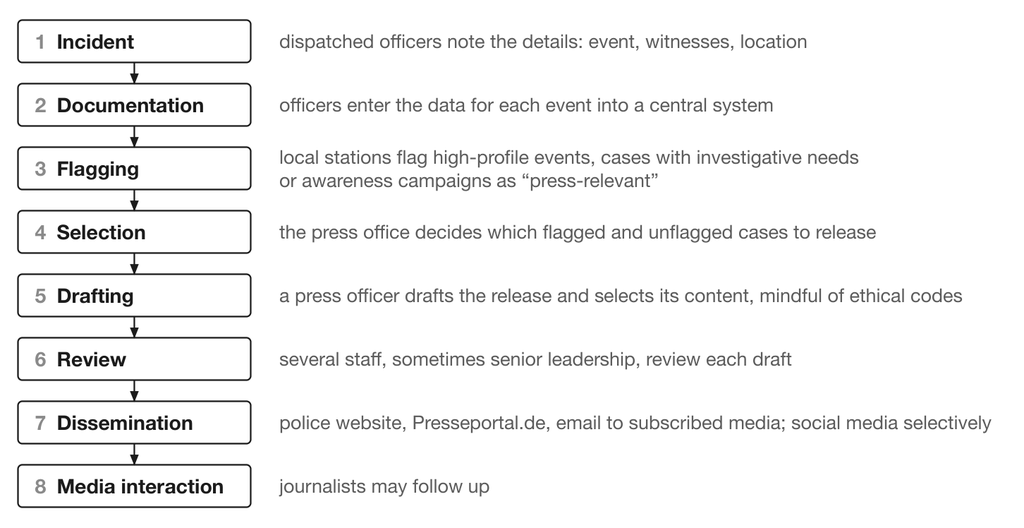

Only a tiny share of recorded crime gets a press release. Press offices ~6–8 staff; every release is written by hand.

← Appendix index

## Why not a demand-side story?

- About **75%** of releases are published on the **day of the event or the day after** — too fast for newsrooms to have already shaped what the police write
- Local media’s **structural constraints** amplify this supply-side power: lacking investigative resources, many outlets publish police press releases **verbatim**, often through **direct feeds**

← Appendix index

## Appendix — News media rely on police

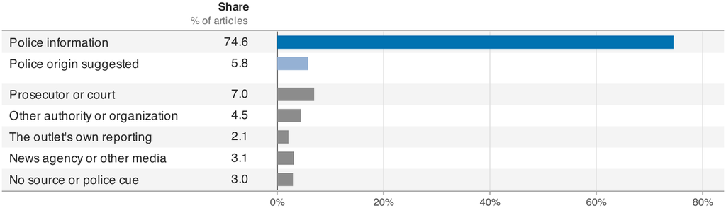

← Appendix index

## Appendix Table B.1 — Coded variables in the analysis dataset

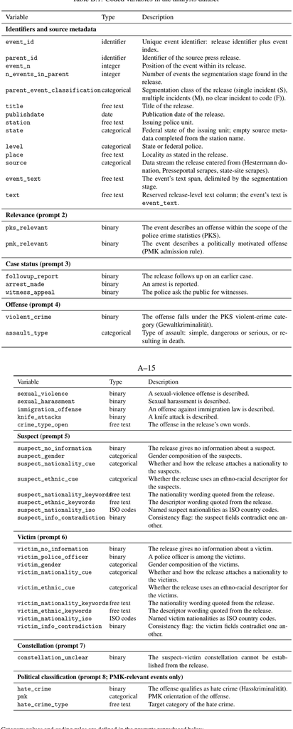

← Appendix index

## Appendix Table C.1 — State-years, cues, and quantities in the descriptive figures

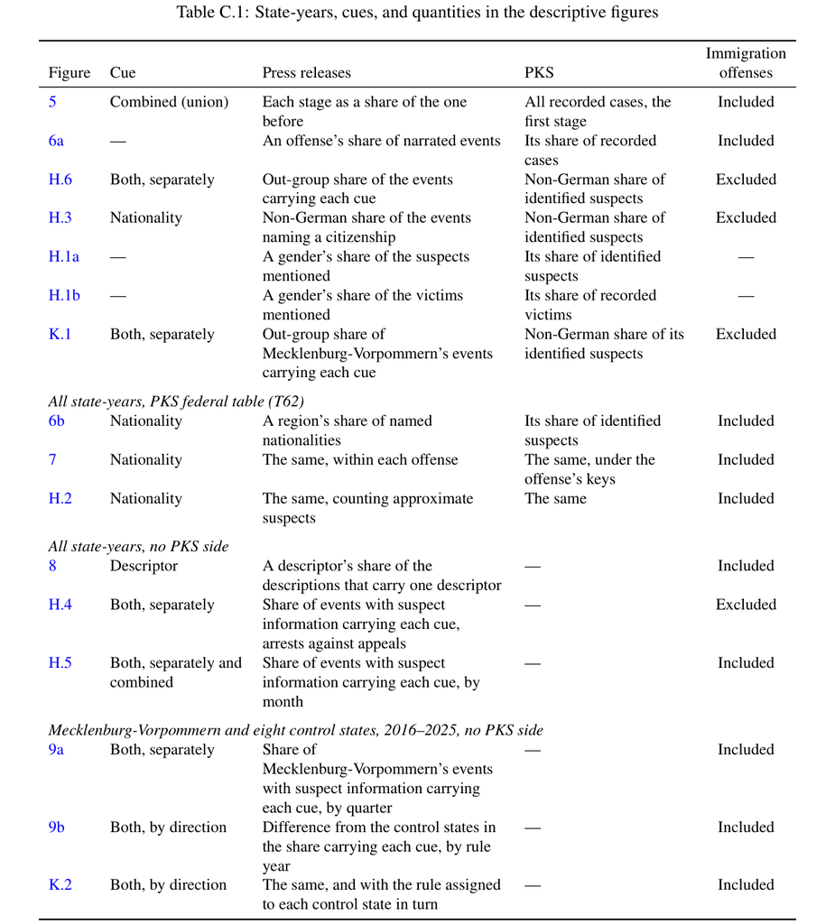

← Appendix index

## Appendix Table D.1 — State-years included in the PKS comparison, 2014–2025

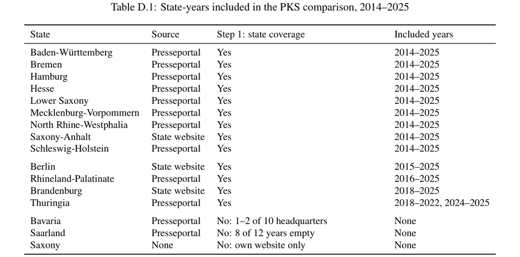

← Appendix index

## Appendix Figure D.1 — Press-release coverage by state and month, 2014–2025

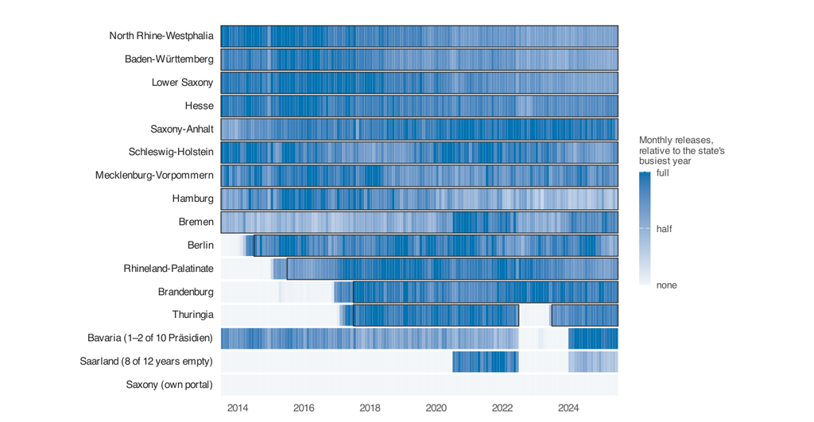

← Appendix index

## Appendix Table D.2 — Pooled comparisons with and without the coverage restriction

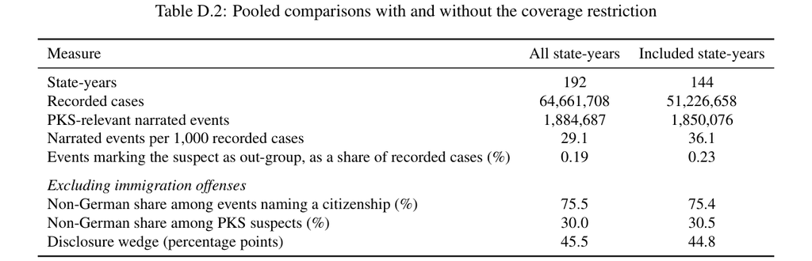

← Appendix index